# Reducción de la dimensión: PCA y LDA

Santander MetGroup

# 1 Introducción:

Un problema habitual en espacios de alta dimensionalidad es la existencia de dependencias y/o correlaciones entre las diferentes variables del problema. Este problema puede resolverse de diversos modos, siendo un método estándar el análisis de componentes principales ([PCAs](https://en.wikipedia.org/wiki/Principal_component_analysis)) ó funciones ortogonales empíricas ([EOFs](https://en.wikipedia.org/wiki/Empirical_orthogonal_functions)). El objetivo de las PCAs es eliminar la información redundante minimizando la pérdida de variabilidad, a través de la proyección de los datos en un nuevo espacio de menor dimensión que el original, en el cual las dimensiones representan aquellas direcciones del espacio donde los datos presentan mayor varianza. Este tipo de análisis puede resultar útil por diversas razones, como por ejemplo:

- nuestra capacidad de visualización de los datos se limita a 2 ó 3 dimensiones;
- la reducción de la dimensión tiene asociada una reducción significativa de los tiempos de cómputo y del coste computacional;
- finalmente, muchos métodos estadísticos son muy sensibles a la correlación entre las variables predictoras, por lo que es necesario considerar predictores independientes, como los obtenidos con el PCA.

Notar que el PCA se enmarca dentro del aprendizaje no supervisado, en el sentido de que sólo considera las dimensiones de los datos, no la variable respuesta.

Un ejemplo típico son los campos de circulación atmosférica, dados por los valores de una o varias magnitudes (la presión a nivel del mar, etc.) en una rejilla sobre una cierta zona de interés. Dado que estas magnitudes están correlacionadas espacialmente, existirá una gran redundancia en esta forma de expresar los datos y, por lo tanto, el análisis de componentes principales permite reducir la dimensión del espacio preservando el máximo de varianza de la muestra. Para ello, la base del nuevo espacio se forma con aquellos vectores donde la muestra proyectada presenta mayor varianza. Los vectores de esta base son de enorme utilidad en meteorología, pues los primeros de ellos pueden corresponder a patrones dominantes como la Oscilación del Atlántico Norte ([NAO](https://en.wikipedia.org/wiki/North_Atlantic_oscillation)), en el sentido de la variabilidad de la muestra que representan.

Otro uso habitual del PCA es el `filtrado` de ruido en una señal reconstruyendola a partir de un número reducido de PCs que contengan los modos de variabilidad principales.

# 2 Cálculo de las Componentes Principales:

Como hemos explicado en la sección anterior, el objetivo del PCA es encontrar un espacio de dimensión baja que contenga toda la información posible respecto a la variabilidad de los datos. La premisa es que, aunque las observaciones estén contenidas en un espacio p-dimensional no todas las dimensiones son independientes o igualmente relevantes. En este caso, la relevancia se define como el porcentaje de variabilidad que es capaz de explicar cada dimensión. Por lo tanto, se buscan nuevas dimensiones que sean lo más relevantes posibles, siendo éstas combinaciones lineales de las originales.

Pero, dado un conjunto `n` observaciones p-dimensionales $X = (X_{1}, X_{2}, \dots, X_{p})$ ¿cómo obtenemos las CPs? Para la primera CP estamos buscando una combinación lineal $z_{i1} = \phi_{11}x_{i1} + \phi_{21}x_{i2} + \dots + \phi_{p1}x_{ip}$ que maximice la varianza muestral sujeta a la restricción de normalización $\sum_{j=1}^{p}\phi_{j1}^{2} = 1$. Es decir, tenemos el siguiente problema de maximización:

$$\stackrel{\hbox{maximize}}{\hbox{$\phi_{11}, \dots ,\phi_{p1}$}} \left\lbrace \frac{1}{n}\sum_{i=1}^{n}(\sum_{j=1}^{p}\phi_{j1}x_{ij}) \right\rbrace$$

sujeto a $\sum_{j=1}^{p}\phi_{j1}^{2} = 1$. Es decir, buscamos maximizar $\frac{1}{n}\sum_{i=1}^{n}z_{i1}^{2}$ que se corresponde con la varianza de $Z_{1}$ si consideramos que $\frac{1}{n}\sum_{i=1}^{n}x_{ij} = 0$ para toda $X_{j}$. Notar que considerar las variables centradas (con media nula) no afecta a la solución de nuestro problema de modo que, en la práctica, se suelen `centrar` las variables antes de estimar las PCs.

El problema anterior puede resolverse a través de la descomposición en valores y vectores propios de la matriz de varianzas y covarianzas, obtenida a partir de la muestra: $Cov(X_{i},X_{j}) = E[(X_{i} - E[X_{i}]) \cdot (X_{j} - E[X_{j}])]$. En el caso de considerar las variables centradas, la fórmula se simplifica a $Cov(X_{i},X_{j}) = E[X_{i} \cdot X_{j}] = \frac{1}{n}\sum_{k=1}^{n}x_{ki} \cdot x_{kj}$. Esta matriz de varianzas y covarianzas es cuadrada y simétrica, de modo que podemos obtener una nueva base ortogonal calculando sus autovalores y los correspondientes autovectores. Los autovectores ($Z_{j}$) se corresponderán con las EOFs, mientras que los autovalores ($\lambda_{j}$) indican la varianza explicada (la varianza de la muestra proyectada sobre el vector) y los coeficientes de un punto (dato) en la nueva base serán las Componentes Principales (CPs).

La resolución de este problema se complica para dimensiones altas por el mal condicionamiento de la matriz de varianzas y covarianzas, de modo que debe recurrirse a métodos numéricos eficientes como la Descomposición en Valores Singulares ([SVD](https://en.wikipedia.org/wiki/Singular_value_decomposition)). La descomposición obtenida cumple que:

- las componetes son independientes,
- los autovectores obtenidos son únicos, salvo cambio en el signo ya que el signo no afecta al cálculo de la varianza,
- la varianza de cada componente se corresponde con el autovalor asociado a dicha componente y, por lo tanto,
- la suma de los autovalores nos da la varianza total.

Al elegir los autovectores en orden decreciente de varianza explicada, es posible hacer una selección de las componentes consideradas reteniendo la máxima varianza posible sin más que seleccionar las $p^{*}$ primeras componentes. De las propiedades anteriores se sigue de forma natural la definición de uno de los parámetros usados habitualmente para la selección de las CPs, el Porcentaje de Varianza Explicada (PVE)
$$PVE_{m} = \frac{\lambda_{m}}{\sum_{j=1}^{p}} \lambda_{j}$$
.

## 2.1 Ejemplo:

A continuación ilustraremos cómo funciona el análisis de componentes principales utilizando el dataset acciones, tomado de Peña (2002). Este conjunto de datos presenta 34 observaciones, correspondientes a distintas acciones que cotizan en el mercado continuo español, y 3 variables, correspondientes a tres medidas de rentabilidad de estas acciones durante un periodo de tiempo. Todas las variables están log-transformadas:

- `rentabilidad`: rentabilidad efectiva por dividendos
- `prop div`: proporción de beneficios que va a dividendos
- `a_b_ratio`: ratio entre precio por acción y beneficios.

```r
acciones <- read.csv("~/Dropbox/M1966_DataMining/datasets/acciones.csv")
str(acciones)
```

```
## 'data.frame':    34 obs. of  3 variables:
##  $ rentabilidad: num  1.22 1.63 1.5 1.25 1.77 ...
##  $ prop_div    : num  4.5 4.02 3.96 3.85 3.75 ...
##  $ a_b_ratio   : num  3.41 2.29 2.44 2.42 1.95 ...
```

En primer lugar obtendremos la matriz de varianzas-covarianzas de los datos. Para ello usaremos la función `cov`.

```r
X <- as.matrix(acciones)
# Matriz de varianzas-covarianzas:
S <- cov(X)
```

Dado que S es una [matriz semidefinida positiva](https://en.wikipedia.org/wiki/Positive-definite_matrix), es posible diagonalizarla obteniendo los valores propios ($\lambda$), que se corresponden con las raíces del polinomio característico

$$\vert S - \lambda Id \vert = -\lambda^{3}+0.64\lambda^{2}-0.0628\lambda+0.000382.$$

De forma gráfica, la raíces se corresponden con los puntos de corte de la curva $f(x) = -x^{3}+0.64x^{2}-0.0628x+0.000382.$ con el eje X.

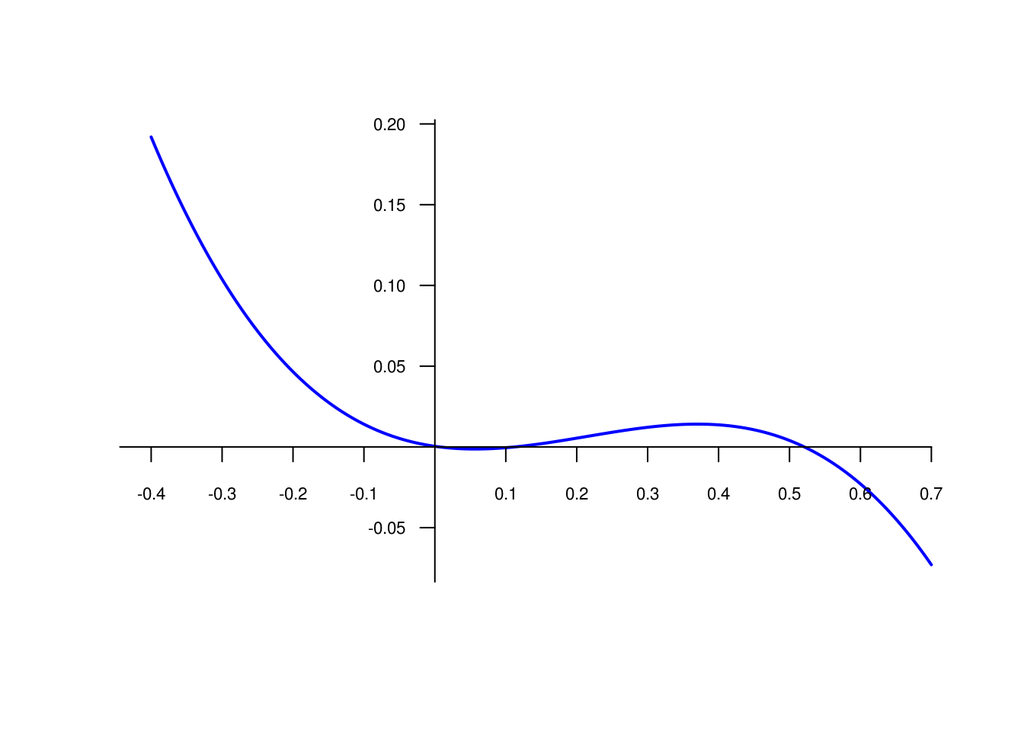

```r
f <- function(x) {-x^3 + 0.64*x^2 - 0.0628*x + 0.000382}
# Genera Figura 1:
a <- curve(f, from = -.4, to = .7, lwd = 2, col = "blue", n = 1000, axes = FALSE,
xlab = "", ylab = "")
axis(side = 1, at = seq(-.5,.7,.1)[-6], pos = 0, cex.axis = .7)
axis(side = 2, at = seq(-.5,.5,.05)[-11], pos = 0, las = 1, cex.axis = .7)
```

Las raíces pueden calcularse analíticamente con la función `uniroot`, para los intervalos dados, tras observación del gráfico anterior:

```r
x.ranges <- c(0, 0.05, 0.2, 0.6)
valores.propios <- sapply(1:ncol(S), function(i) uniroot(f, lower = x.ranges[i],
                                                 upper = x.ranges[i + 1])$root)
(valores.propios <- sort(valores.propios, decreasing = TRUE))
```

```
## [1] 0.520828897 0.112664541 0.006507595
```

Esta raíces son los valores propios (eigenvalues) del polinomio. En particular, el vector propio asociado al mayor de ellos ($\lambda_{1} = 0.521$) es el que da los pesos de la primera componente principal (CP), el segundo ($\lambda_{2} = 0.113$) a la segunda CP y el tercero ($\lambda_{3} = 0.0065$) a la tercera CP. La varianza recogida por cada CP puede calcularse como el cociente entre el valor propio de esa CP y el total:

```r
pve <- 100*valores.propios/sum(valores.propios)
pve
```

```
## [1] 81.37938 17.60381  1.01681
```

```r
cpve <- cumsum(100*valores.propios/sum(valores.propios))
cpve
```

```
## [1]  81.37938  98.98319 100.00000
```

lo que quiere decir que la primera componente principal recoge la mayor parte de la varianza (el $81.3\%$), la segunda el $17.6\%$ y la tercera apenas un $1\%$. Por lo tanto, en este caso sería razonable descartar la tercera componente y quedarnos con las dos primeras, de modo que el conjunto de datos original, formado por tres variables, quedaría reducido a dos CPs que recogen el $99\%$ de la varianza total de los datos.

En la práctica, los valores propios de las matrices extensas no se calculan usando el polinomio característico. Calcular el polinomio resulta muy costoso, y extraer las raíces exactas de un polinomio de grado alto puede ser una tarea compleja. Existen algoritmos eficientes para aproximar raíces de polinomios, aunque pequeños errores en la estimación de los valores propios pueden dar lugar a errores grandes en los vectores propios. Por ello, los algoritmos usados para encontrar vectores propios y valores propios son iterativos. En ocasiones puede resultar en errores si no se alcanza la convergencia (ver `help("eigen")` ó `? eigen`). En `R`, y en gran parte de los lenguajes de programación, estos algoritmos se encuentran incluídos en el paquete de álgebra lineal especializado LAPACK, a los que se accede mediante las funciones `eigen` o `svd` (singular value decomposition). En general, la descomposición en valores singulares es más estable numéricamente que la descomposición por valores propios, por lo que es preferible de forma general el uso de `svd` sobre `eigen`.

```r
svd(S)
```

```
## $d
## [1] 0.53484436 0.11487209 0.01074318
##
## $u
##            [,1]       [,2]       [,3]
## [1,] -0.8193833 0.03234301 -0.5723329
## [2,] -0.3475875 0.76589987  0.5409070
## [3,]  0.4558443 0.64214587 -0.6163235
##
## $v
##            [,1]       [,2]       [,3]
## [1,] -0.8193833 0.03234301 -0.5723329
## [2,] -0.3475875 0.76589987  0.5409070
## [3,]  0.4558443 0.64214587 -0.6163235
```

```r
eigen(S)
```

```
## eigen() decomposition
## $values
## [1] 0.53484436 0.11487209 0.01074318
##
## $vectors
##            [,1]       [,2]       [,3]
## [1,]  0.8193833 0.03234301  0.5723329
## [2,]  0.3475875 0.76589987 -0.5409070
## [3,] -0.4558443 0.64214587  0.6163235
```

Nótese la leve diferencia en la estimación de los valores propios (objeto `eigenval`) frente a la aproximación anterior utilizando el polinomio característico (objeto `valores.propios`). Los pesos de la primera componente principal, vienen dados por el vector propio correspondiente al primer valor propio. Guardaremos los vectores propios en el objeto `eigenvec`:

```r
eigenval <- svd(S)$d
eigenvec <- svd(S)$v
```

Por lo tanto, la primera componente principal viene dada por la siguiente expresión, cuyos factores vienen dados por la primera columna de la matriz de vectores propios anterior:

$$Z_{1} = -0.819x_{1} - 0.348x_{2} + 0.456x_{3}$$

donde $x_{i}$ son las variables del conjunto del conjunto de datos `acciones`. Del mismo modo, las restantes componentes principales se calculan a partir de los vectores propios de sus respectivas columnas. Los valores de la primera CP pueden calcularse multiplicando cada fila de la matriz de observaciones (objeto `X`) por el vector propio de la primera CP, de acuerdo con la expresión anterior:

```r
cp1 <- -0.819*X[ ,1] - 0.348*X[ ,2] + 0.456*X[ ,3]
head(cp1)
```

```
## [1] -1.013068 -1.687905 -1.495164 -1.264208 -1.872812 -1.644082
```

Por lo tanto, la tabla de las 3 CPs correspondientes a cada una de las 3 variables del conjunto de datos puede calcularse a través de la siguiente expresión (las guardaremos en la matriz `CPscores`):

```r
CPscores <- t(t(eigenvec) %*% t(X))
head(CPscores)
```

```
##           [,1]     [,2]       [,3]
## [1,] -1.012213 5.671759 -0.3685677
## [2,] -1.687228 4.603739 -0.1709758
## [3,] -1.494488 4.647652 -0.2257420
## [4,] -1.263476 4.540715 -0.1234103
## [5,] -1.872247 4.182306 -0.1845015
## [6,] -1.643596 3.913156 -0.2724673
```

Como dijimos en la sección anterior, la primera componente principal recoge la mayor parte de la varianza de los datos. Cabe preguntarse con qué variable(s) tiene una relación más clara. Podemos evaluar esto de manera informal mediante un diagrama de dispersión que enfrente los valores de la primera CP (`scores`) frente a cada una de las variables originales:

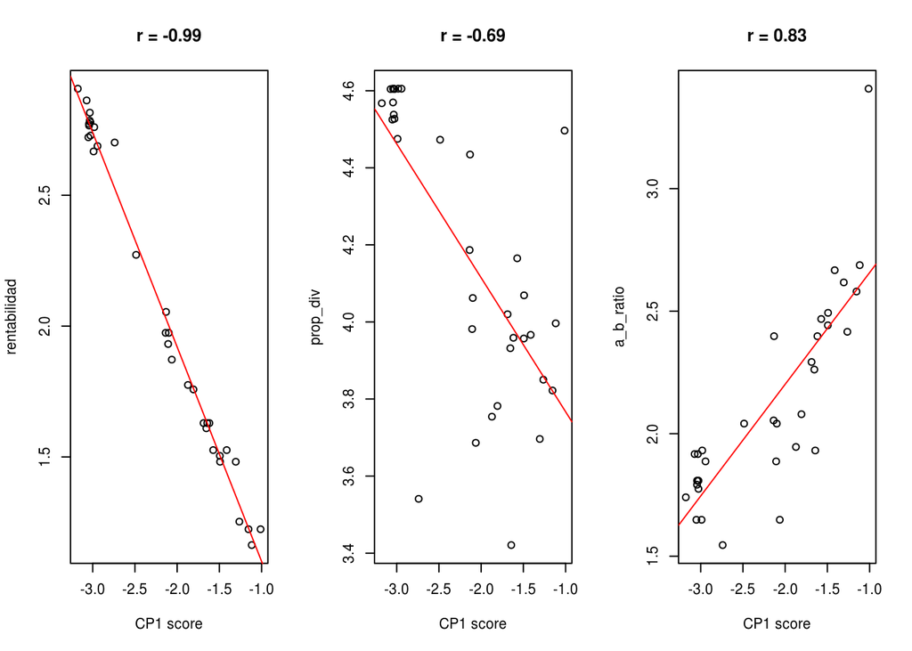

```r
# Genera Figura 2
par(mfrow = c(1,3))
var <- names(acciones)
for (i in 1:length(acciones)) {
      plot(CPscores[ ,1], X[ ,i], ylab = var[i], xlab = "CP1 score")
      abline(reg = lm(X[ ,i] ~ CPscores[ ,1]), col = "red")
      title(paste0("r = ", round(cor(X[ ,i], CPscores[ ,1]),2)))
}
```

```r
par(mfrow = c(1,1))
```

Este resultado indica que la primera componente principal depende básicamente de la variable $x_{1}$, que corresponde con la rentabilidad efectiva por dividendos, con una correlación de -0.99.

## 2.2 Rescalado de las variables:

Como hemos visto anteriormente, centrar las variables es una práctica habitual antes del cálculo de las PCs que no afecta al resultado final por las propiedades de la varianza respecto a transformaciones aditivas. Sin embargo, al multiplicar una variable por una constante la varianza se ve afectada por el cuadrado de ese factor, ¿cómo afecta el rescalado de las variables a las PCs obtenidas? En el caso en que las diferentes variables presentasen varianzas muy diferentes, que suele ser lo habitual, el rescalado de las variables cambia de forma drástica las PCs obtenidas. Dado que el PCAs busca la dirección de mayor variabilidad, la primera CP se verá `sesgada` hacia la variable de mayor variabilidad en el caso de considerar las variables originales. El mismo problema se extiende al resto de CPs dando lugar a un conjunto de direcciones `sesgado` hacia las dimensiones de mayor varianza en las variables originales.

Para evitar el problema anterior, además de centrar las variables éstas son estandarizadas (componente a componente) de modo que se eliminan los efectos de las diferentes escalas de las variables originales. Otro modo para tener en cuente este problem es considerar en el análisis la matriz de correlaciones en lugar de la de varianzas y covarianzas.

## 2.3 Evaluación de la adecuidad de aplicar PCA:

El cálculo de PCs para la reducción de la dimensión se fundamenta implícitamente en que existe cierta dependencia entre las variables, que permite esta reducción de la dimensión. Sin embargo, puede darse el caso de que las variables sean independientes y que el cálculo de las PCs no nos permita una reducción clara de la dimensión. Para identificar este caso es útil el [Test de Esfericidad de Barttlet](https://en.wikipedia.org/wiki/Bartlett's_test) el cual, aplicado a la matriz de correlaciones, identifica cuantos grados de libertad teóricos existen en las variables consideradas. En el caso de variables independientes, la matriz de correlaciones coincidiría con la identidad y se obtendrían tantos grados de libertad como variables se consideren. Sin embargo, a medida que la dependencia entre variables aumenta, los grados de libertad se reducen y, por lo tanto, resulta justificable la aplicación del PCA. El Test de Esfericidad de Barttlet se encuentra en el paquete `psych`, por lo que, para su aplicación, necesitaríamos instalar el paquete:

```r
## If psych packages is not installed you should execute this line:
# install.packages("psych")
library(psych)
```

A continuación, calculamos la matriz de correlaciones y evaluamos los grados de libertad (`df`) obtenidos:

```r
X <- as.matrix(acciones)
# Matriz de correlaciones
correl <- cor(X, method = "pearson")
cortest.bartlett(correl, n = nrow(X))
```

[output not shown]

## 2.4 Regresion sobre las componentes principales:

Uno de los usos habituales del PCA es para eliminar la colinearidad entre variables en problemas de regresión, de modo que se consideran las PCs como predictores en lugar de las variables originales. Si bien, efectivamente, trabajar con PCs elimina los problemas numéricos asociados a la colinearidad de variables en la regresión, como fue descrito por [Ali et al. 1998](http://amstat.tandfonline.com/doi/abs/10.1080/00031305.1998.10480530) pueden aparecer otros problemas al trabajar con las PCs, como, por ejemplo, que todo el peso del modelo de regresión recaiga sobre la última PC, que suele ser eliminada por ser la que menos porcentaje de varianza explica. Por lo tanto, es importante analizar los resultados obtenidos en uno u otro caso para evitar este tipo de problemas al utilizar PCs en un modelo de regresión.

## 2.5 Aplicación práctica con R

Existen numerosas funciones en R que realizan, de forma explícita o implícita, un PCA de los datos. En este apartado, nos centraremos en una de las más utilizadas, la función `prcomp`, y analizaremos las diferentes componentes, opciones y estructura de salida de dicha función.

Aplicaremos el PCA a las tres variables continuas que forman el conjunto de datos `acciones`. Nótese que este dataset ya se encuentra transformado logarítmicamente. Como norma general, es altamente recomendable estandarizar los datos antes de realizar el PCA. Esto puede realizarse como paso previo a la llamada de la función `prcomp`, utilizando la función `scale`, o bien a través de los argumentos `center` y `scale`. En nuestro caso, mantendremos los datos originales utilizados en el apartado anterior, por comparabilidad de resultados.

```r
str(scale(acciones))
```

```
##  num [1:34, 1:3] -1.408 -0.735 -0.943 -1.36 -0.493 ...
##  - attr(*, "dimnames")=List of 2
##   ..$ : NULL
##   ..$ : chr [1:3] "rentabilidad" "prop_div" "a_b_ratio"
##  - attr(*, "scaled:center")= Named num [1:3] 2.07 4.18 2.12
##   ..- attr(*, "names")= chr [1:3] "rentabilidad" "prop_div" "a_b_ratio"
##  - attr(*, "scaled:scale")= Named num [1:3] 0.602 0.368 0.403
##   ..- attr(*, "names")= chr [1:3] "rentabilidad" "prop_div" "a_b_ratio"
```

```r
pca <- prcomp(acciones)
```

### 2.5.1 Análisis de los resultados

El objeto `pca` contiene los resultados del análisis de componentes principales realizado. La función `prcomp` devuelve un objeto de la clase `"prcomp"`, con algunos métodos asociados útiles para la exploración y análisis de los resultados.

#### 2.5.1.1 print.prcomp

El método `print` devuelve la desviación típica de cada una de las 3 PCs, así como sus pesos (también referidos como pesos `loadings`) o en este caso rotaciones (`rotation`), que son los vectores propios, es decir, los coeficientes de las combinaciones lineales de las variables (ver resultados de la seccion anterior).

```r
class(pca)
```

```
## [1] "prcomp"
```

```r
print(pca)
```

```
## Standard deviations (1, .., p=3):
## [1] 0.7313305 0.3389279 0.1036493
##
## Rotation (n x k) = (3 x 3):
##                     PC1         PC2        PC3
## rentabilidad  0.8193833 -0.03234301  0.5723329
## prop_div      0.3475875 -0.76589987 -0.5409070
## a_b_ratio    -0.4558443 -0.64214587  0.6163235
```

#### 2.5.1.2 plot.prcomp

El método `plot` devuelve un gráfico de las varianzas (eje Y) asociada con cada PC (eje X). Este gráfico es útil para decidir cuántas PCs retener para análisis posteriores. De forma alternativa, puede utilizarse la función `screeplot` con el mismo fin.

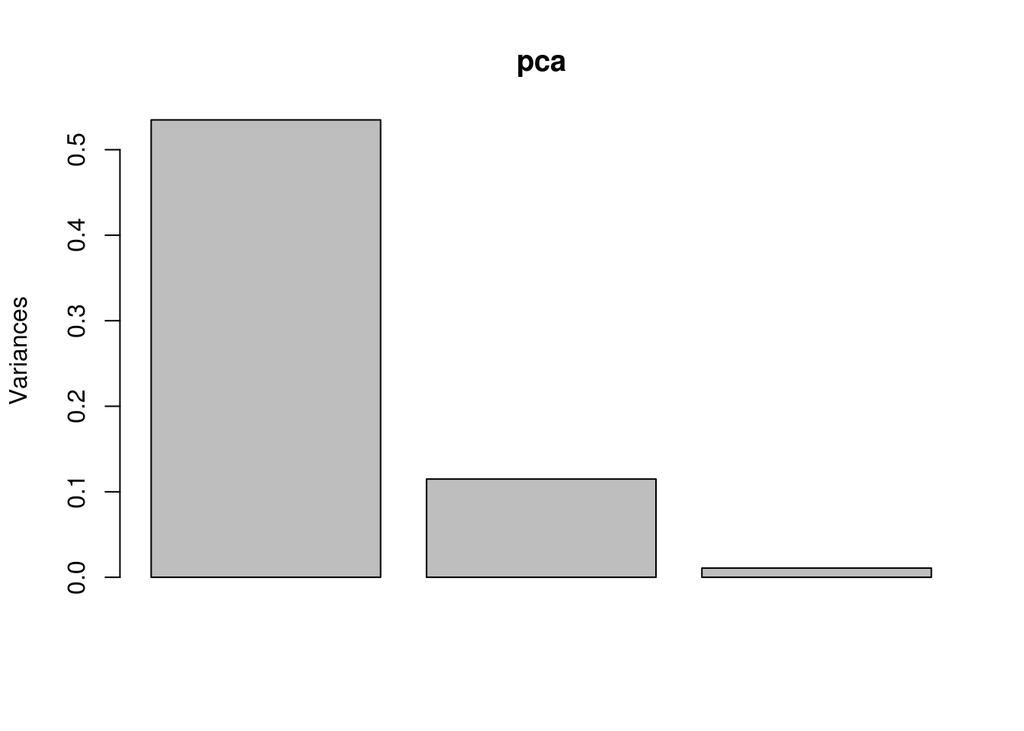

```r
# Genera Figura 3
plot(pca)
```

A partir de la figura anterior es fácil ver que las dos primeras PCs, y sobretodo la primera, recogen la mayor parte de la varianza, como ya vimos anteriormente.

#### 2.5.1.3 summary.prcomp

El método `summary` describe la importancia de cada PC. La primera fila repite la información antes vista de las desviaciones típicas asociadas a cada PC. La segunda fila muestra la proporción de varianza de los datos recogida por cada componente. La tercera fila describe la proporción acumulada de dicha varianza. Como vimos anteriormente, la primera PC recoge el $81\%$ de la varianza total de los datos.

```r
summary(pca)
```

```
## Importance of components:
##                           PC1    PC2     PC3
## Standard deviation     0.7313 0.3389 0.10365
## Proportion of Variance 0.8098 0.1739 0.01627
## Cumulative Proportion  0.8098 0.9837 1.00000
```

#### 2.5.1.4 predict.prcomp

El método `predict` aplicado sobre un objeto PCA de la `"prcomp"` para predecir los valores que tendrán las CPs para nuevos valores observados. Para ilustrarlo, supongamos que los tres últimos datos del conjunto de datos `acciones` son nuevos datos de cotización que acabamos de obtener:

```r
predict(pca, newdata = tail(acciones,3))
```

```
##            PC1       PC2        PC3
## 32 -0.07866906 0.3035111 -0.1154347
## 33  0.80437382 0.0548297 -0.1082482
## 34  0.55471463 0.8354406  0.3529290
```

Compárense con los valores obtenidos por cada PC para estas observaciones:

```r
tail(pca$x, 3)
```

```
##               PC1       PC2        PC3
## [32,] -0.07866906 0.3035111 -0.1154347
## [33,]  0.80437382 0.0548297 -0.1082482
## [34,]  0.55471463 0.8354406  0.3529290
```

Los resultados del PCA suelen representarse a través de los llamados `biplots`, generados mediante la función con el mismo nombre. Las variables se representan mediante flechas, y los números representan las filas de cada observación en la tabla de datos original. Las direcciones de las flechas muestran los pesos relativos de cada variable en la primera y segunda componente principal (por defecto se represntan la CP1 frente a la CP2, aunque esto puede modificarse a través del argumento `choices` (ver `help("biplot.princomp")`).

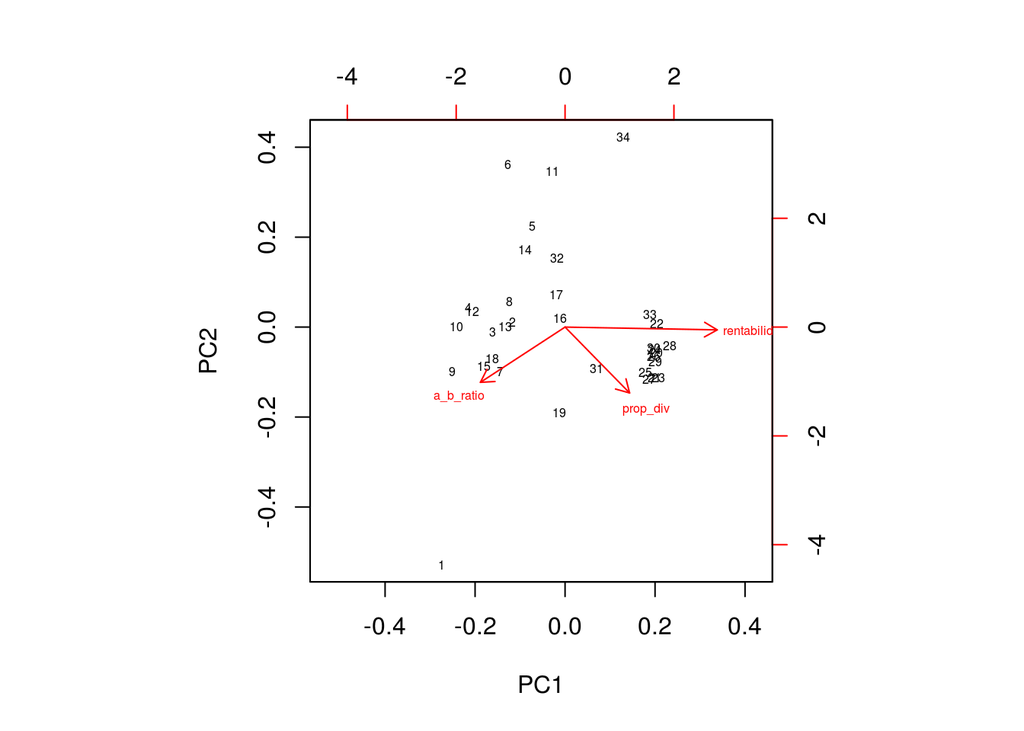

```r
# Genera Fig. 4
biplot(pca, cex = .5)
```

La estandarización de los datos es especialmente útil para poder visualizar de forma adecuada los biplots, ya que de este modo los valores de los ejes de las PCs se mantienen dentro del mismo rango:

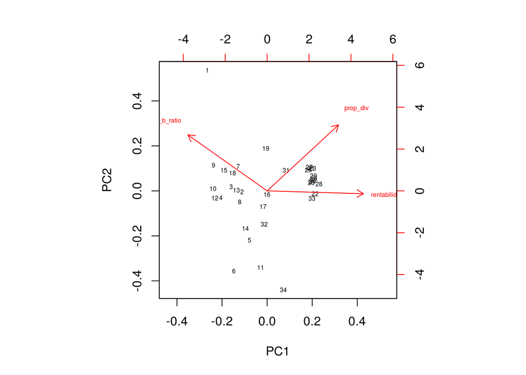

```r
# Genera Fig. 5
pca2 <- prcomp(acciones, center = TRUE, scale. = TRUE)
biplot(pca2, cex = .5)
```

El paquete `ggbiplot` proporciona interesantes opciones de visualización, más allá de la función `biplot`. Se encuentra disponible en GitHub, desde donde puede instalarse fácilmente con la función `install_github`:

```r
library(devtools)
install_github("ggbiplot", "vqv")
```

A continuación se muestra un ejemplo de la función `ggbiplot`:

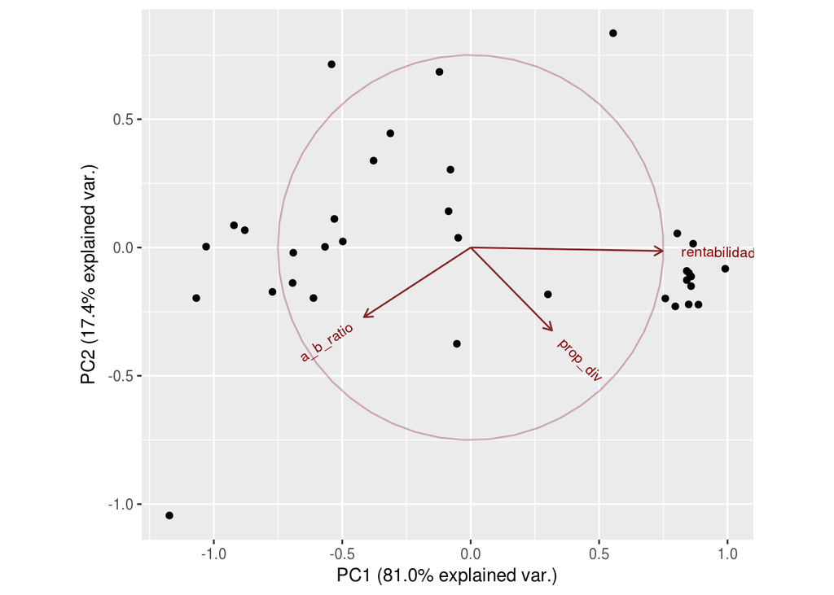

```r
library(ggbiplot)
# Genera Fig. 6
g <- ggbiplot(pca, obs.scale = 1, var.scale = 1, ellipse = TRUE, circle = TRUE)
g <- g + scale_color_discrete(name = '')
g <- g + theme(legend.direction = 'horizontal', legend.position = 'top')
print(g)
```

# 3 Reducción de la dimensionalidad con PCA

## 3.1 MNIST data set from kaggle - Reconstrucción

Para analizar la reducción de la dimensionalidad a través del análisis de componentes principales consideraremos inicialmentre el dataset [MNIST](https://www.kaggle.com/c/digit-recognizer/data), ya descrito en prácticas anteriores. Dibujaremos inicialmente algunas de las imágenes:

```r
# Reading dataset
library("readr")
mnist_data <- read_csv("~/Dropbox/M1966_DataMining/datasets/train.csv")
```

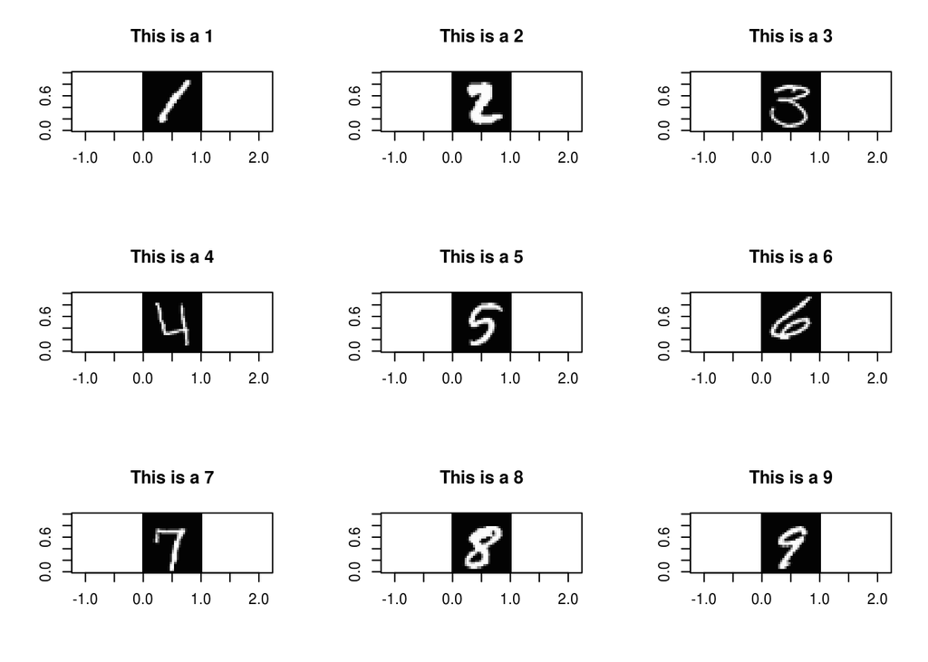

```r
# Building a 3*3 grid
par(mfrow=c(3,3))
for (i in 1:9){
  i1 <- min(which(mnist_data$label == i))
  # Changing i-th row to matrix
  mat <- matrix(as.numeric(mnist_data[i1,ncol(mnist_data):2]), nrow = 28, ncol=28, byrow = FALSE)
  # Inverting row order
  mat <- mat[nrow(mat):1,]
  # plot
  image(mat, main=paste0("This is a ", mnist_data[i1,1]), col=paste("gray", 1:99,sep=""), asp = 1)
}
```

Notar que hay píxeles que siempre toman el valor 0, o uno constante, y, por lo tanto, no aportan información, de modo que podrían filtrarse del análisis, y, en caso de necesitar rescalar los datos, introducen poblemas de inestabilidad numérica al dividir por 0.

En nuestro caso, no existe necesidad de reescalar los datos ya que todos tienen el mismo orden de magnitud, podemos calcular las PCs sin filtrar los píxeles constantes:

```r
# PCA with R
nrows <- 42000 # set number of rows to include. Max = 42000
PCA1 <- prcomp(mnist_data[1:nrows,(2:ncol(mnist_data))], center = TRUE, scale. = FALSE)
```

El parámetro `nrows` nos permite disminuir el número de imágenes si el coste computacional de usar las 42000 posibles es muy alto. Como se ha explicado, cada componente principal tiene asociada una varianza explicada:

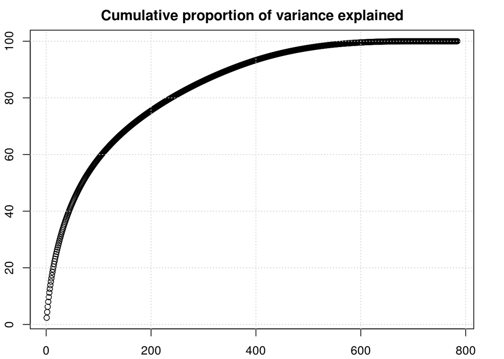

```r
par(mfrow=c(1,1), mar=c(2.1,2.1,2.1,2.1))
plot(cumsum(PCA1$sdev)/sum(PCA1$sdev)*100,main="Cumulative proportion of variance explained")
grid()
```

Como vemos, de las 784 dimensiones posibles 200 explican casi el 80% de la varianza. Por lo tanto, si este subconjunto es suficientemente representativo podemos considerar únicamente ese subconjunto y, por tanto, reducir la dimensionalidad del problema.

Reconstruyamos las imágenes utilizando diferentes número de PCs para ver si es posible considerar ese subconjunto para realizar la clasificación. Visualicemos la primera PC:

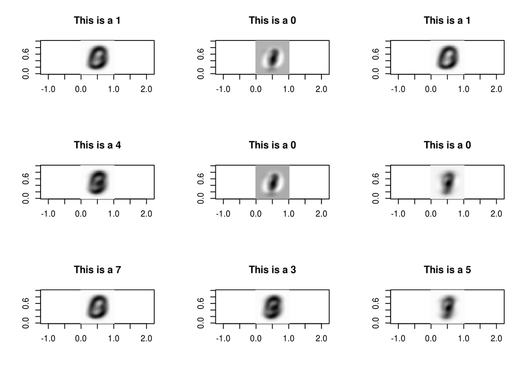

```r
# number of projected data
Nima <- 9 # Number of images
proj_id <- 1:Nima
Ncp <- 1 # Number of PCs
projected <- scale(as.matrix(PCA1$x[proj_id,1:Ncp]) %*% t(as.matrix(PCA1$rotation[,1:Ncp])), PCA1$center, PCA1$scale)
par(mfrow=c(3,3))
for (i in 1:9){
  # Changing i-th row to matrix
  mat <- matrix(as.numeric(projected[i,]), nrow = 28, ncol=28, byrow = FALSE)
  # Inverting columns order
  mat <- mat[,ncol(mat):1]
  # plot
  image(mat, main=paste0("This is a ", mnist_data[i,1]), col=paste("gray", 1:99,sep=""), asp = 1)
}
```

Como vemos, debemos considerar un mayor número de PCs para poder clasificar las imágenes, probemos con las 200 que explican el 80% de la varianza:

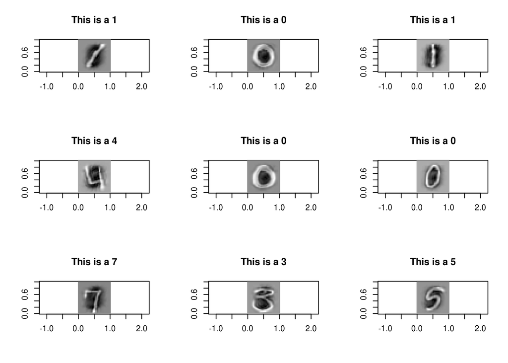

```r
# number of projected data
Nima <- 9 # Number of images
proj_id <- 1:Nima
Ncp <- 200 # Number of PCs
projected <- scale(as.matrix(PCA1$x[proj_id,1:Ncp]) %*% t(as.matrix(PCA1$rotation[,1:Ncp])), PCA1$center, PCA1$scale)
par(mfrow=c(3,3))
for (i in 1:9){
  # Changing i-th row to matrix
  mat <- matrix(as.numeric(projected[i,]), nrow = 28, ncol=28, byrow = FALSE)
  # Inverting columns order
  mat <- mat[,ncol(mat):1]
  # plot
  image(mat, main=paste0("This is a ", mnist_data[i,1]), col=paste("gray", 1:99,sep=""), asp = 1)
}
```

A medida que incorporamos PCs más nos aproximamos a la imagen original. Con 1 PC se pierde demasiada información, como se veía tanto en el gráfico de varianza explicada como en el de representación de las imágenes, mientras que con 100 ó 200 PCs los dígitos son suficientemente reconocibles como para obtener un modelo con precisión similar a la que obtendríamos considerando todas las dimensiones.

## 3.2 Gene expression - Sobreajuste

El caso anterior con MNIST ya nos permitió ver como reducir la dimensionalidad de los datos a través del análisis de componentes principales. Sin embargo, como vimos en sesiones anteriores, en el caso del dataset de [Gene expression](https://www.kaggle.com/crawford/gene-expression) en casos de leucemia aguda la reducción de la dimensionalidad es necesaria para el aprendizaje de cualquier modelo sin incurrir en sobreajuste.

Por ello, apliquemos PCAs a estos datos y veamos como afecta esta reducción al ajuste de los modelos ya vistos en otras sesiones. Carguemos los datos necesarios:

```r
library(ggplot2) # Data visualization
library(tidyverse)
library(caret) # Model learning and evaluation
## Let's START - importing training set into trainDF variable
trainDF <- read_csv("~/Dropbox/M1966_DataMining/datasets/gene-expression/data_set_ALL_AML_train.csv")
testDF <- read_csv("~/Dropbox/M1966_DataMining/datasets/gene-expression/data_set_ALL_AML_independent.csv")
actual <- read_csv("~/Dropbox/M1966_DataMining/datasets/gene-expression/actual.csv")
## Storing new column headers (genes access names)
colHead <- as.vector(t(trainDF[,2]))

## Filtering the non relevant fields
trainDF <- trainDF[which(is.element(names(trainDF),actual$patient))]
testDF <- testDF[which(is.element(names(testDF),actual$patient))]

## Obtaining the corresponding labels:
trainLabels <- actual$cancer[which(is.element(actual$patient,names(trainDF)))]
testLabels <- actual$cancer[which(is.element(actual$patient,names(testDF)))]

## Defining the data.frame to learn the corresponding model:
## To this aim we should traspose the data.frame
trainDF <- as.data.frame(t(trainDF))
trainDF$label <- as.factor(t(trainLabels))
names(trainDF)[1:7129] <- c(colHead)

testDF <- as.data.frame(t(testDF))
testDF$label <- as.factor(t(testLabels))
names(testDF)[1:7129] <- c(colHead)
```

Obtenemos las correspondientes PCs:

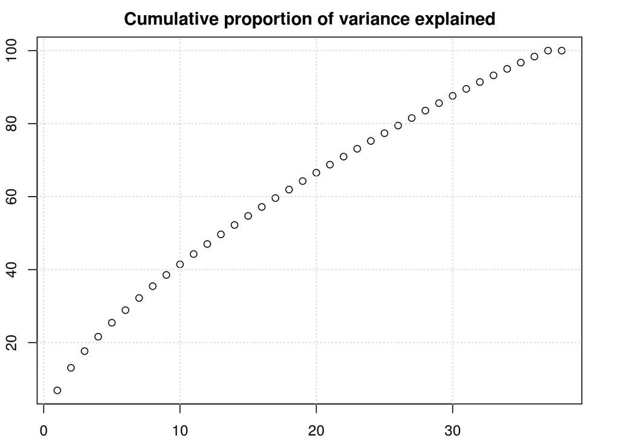

```r
# PCA with R
PCA2 <- prcomp(trainDF[,1:7129], tol = 0, center = TRUE, scale. = TRUE)
par(mfrow=c(1,1), mar=c(2.1,2.1,2.1,2.1))
plot(cumsum(PCA2$sdev)/sum(PCA2$sdev)*100,main="Cumulative proportion of variance explained")
grid()
```

Notar que sólo se obtienen 38 PCs. Si bien, inicialmente podemos interpretar el resultado como erróneo, si hacemos el cálculo de los autovalores de forma explícita

```r
# Do not execute
S <- cov(scale(as.matrix(trainDF[,1:7129]), center = TRUE, scale = TRUE))
v <- eigen(S)
cpve <- cumsum(100*v$values/sum(v$values))
plot(cpve)
```

vemos que a partir de ese número de PCs el autovalor es nulo y, por lo tanto, su contribución a la varianza es nula. Por ese motivo, la función `prcomp` filtra las PCs constantes, siendo una primera disminución de la dimensionalidad.

```r
PCA2 <- prcomp(trainDF[,1:7129], tol = 0, center = TRUE, scale. = TRUE)
trainPC <- trainDF
trainPC$x <- PCA2$x
fitControl <- trainControl(method="none")
modelFit <- train(label ~ x, data=trainPC, method="glm", trControl=fitControl)
pred <- predict(modelFit, newdata = trainPC)
acc<-confusionMatrix(trainPC$label,pred)
print(acc)
```

```
## Confusion Matrix and Statistics
##
##           Reference
## Prediction ALL AML
##        ALL  27   0
##        AML   0  11
##
##                Accuracy : 1
##                  95% CI : (0.9075, 1)
##     No Information Rate : 0.7105
##     P-Value [Acc > NIR] : 2.291e-06
##
##                   Kappa : 1
##  Mcnemar's Test P-Value : NA
##
##             Sensitivity : 1.0000
##             Specificity : 1.0000
##          Pos Pred Value : 1.0000
##          Neg Pred Value : 1.0000
##              Prevalence : 0.7105
##          Detection Rate : 0.7105
##    Detection Prevalence : 0.7105
##       Balanced Accuracy : 1.0000
##
##        'Positive' Class : ALL
##
```

```r
aux <- predict(PCA2, testDF[,1:7129])
testDF$x <- aux
pred <- predict(modelFit, newdata = testDF)
acc<-confusionMatrix(testDF$label,pred)
print(acc)
```

```
## Confusion Matrix and Statistics
##
##           Reference
## Prediction ALL AML
##        ALL  15   5
##        AML   9   5
##
##                Accuracy : 0.5882
##                  95% CI : (0.407, 0.7535)
##     No Information Rate : 0.7059
##     P-Value [Acc > NIR] : 0.9513
##
##                   Kappa : 0.1119
##  Mcnemar's Test P-Value : 0.4227
##
##             Sensitivity : 0.6250
##             Specificity : 0.5000
##          Pos Pred Value : 0.7500
##          Neg Pred Value : 0.3571
##              Prevalence : 0.7059
##          Detection Rate : 0.4412
##    Detection Prevalence : 0.5882
##       Balanced Accuracy : 0.5625
##
##        'Positive' Class : ALL
##
```

Notar que debemos proyectar los datos sobre las PCs obtenidas en el conjunto de entrenamiento. Al seguir incurriendo en sobreajuste, podemos tratar de entrenar un modelo con un número menor de PCs:

```r
trainPC <- trainDF
trainPC$x <- PCA2$x[,1:2]
fitControl <- trainControl(method="none")
modelFit <- train(label ~ x, data=trainPC, method="glm", trControl=fitControl)
pred <- predict(modelFit, newdata = trainPC)
acc<-confusionMatrix(trainPC$label,pred)
print(acc)
```

```
## Confusion Matrix and Statistics
##
##           Reference
## Prediction ALL AML
##        ALL  24   3
##        AML   7   4
##
##                Accuracy : 0.7368
##                  95% CI : (0.569, 0.866)
##     No Information Rate : 0.8158
##     P-Value [Acc > NIR] : 0.9232
##
##                   Kappa : 0.283
##  Mcnemar's Test P-Value : 0.3428
##
##             Sensitivity : 0.7742
##             Specificity : 0.5714
##          Pos Pred Value : 0.8889
##          Neg Pred Value : 0.3636
##              Prevalence : 0.8158
##          Detection Rate : 0.6316
##    Detection Prevalence : 0.7105
##       Balanced Accuracy : 0.6728
##
##        'Positive' Class : ALL
##
```

En esta ocasión, si bien la predicción no es perfecta obtenemos un resultado similar, o comparable, al del conjunto de test, de modo que se elimina/corrige ese sobreajuste observado anteriormente:

```r
aux <- predict(PCA2, testDF[,1:7129])
testDF$x <- aux[,1:2]
pred <- predict(modelFit, newdata = testDF)
acc<-confusionMatrix(testDF$label,pred)
print(acc)
```

```
## Confusion Matrix and Statistics
##
##           Reference
## Prediction ALL AML
##        ALL  19   1
##        AML  12   2
##
##                Accuracy : 0.6176
##                  95% CI : (0.4356, 0.7783)
##     No Information Rate : 0.9118
##     P-Value [Acc > NIR] : 1.000000
##
##                   Kappa : 0.1053
##  Mcnemar's Test P-Value : 0.005546
##
##             Sensitivity : 0.6129
##             Specificity : 0.6667
##          Pos Pred Value : 0.9500
##          Neg Pred Value : 0.1429
##              Prevalence : 0.9118
##          Detection Rate : 0.5588
##    Detection Prevalence : 0.5882
##       Balanced Accuracy : 0.6398
##
##        'Positive' Class : ALL
##
```

# 4 Clasificación y regresión con PCs

Una de las propiedades teóricas de las componentes principales es su ortogonalidad, de modo que, además de permitir la reducción de la dimensionalidad del modelo también elimina los posibles problemas de colinealidades y redundancias de los datos reflejados en sesiones anteriores. Este hecho es especialmente relevante para los modelos de regresión lineal.

## 4.1 Clasificación: MNIST dataset

Consideremos de nuevo el dataset MNIST para clasificar las imágenes con el núnero 9:

```r
# Reading dataset
train <- read_csv("~/Dropbox/M1966_DataMining/datasets/train.csv")
train$label[which(train$label < 9)] <- 0
train$label[which(train$label == 9)] <-1
train$label<-as.factor(train$label)

indTrain <- createDataPartition(train$label,p=0.5,list=FALSE)
trainHO <- train[indTrain,]
testHO <- train[-indTrain,]
fitControl <- trainControl(method="none")

# PCA with R
PCA <- prcomp(trainHO[,(2:ncol(trainHO))], center = TRUE, scale. = FALSE)
```

Ajustemos el modelo con todos los datos de la imagen y veamos los estadísticos de validación que obtenemos tanto para el conjunto de train como el de test:

```r
Npc <- length(PCA$center)
Npcs <- c(seq(1,Npc,60),Npc)
accuracy <- matrix(data = NA, nrow = 1+length(Npcs), 2)
modelFit <- train(label ~ ., data=trainHO, method="glm", trControl=fitControl)
pred <- predict(modelFit, newdata = trainHO[,-1])
acc<-confusionMatrix(trainHO$label,pred)
acc$overall[which(is.element(attr(acc$overall, "names"), "Accuracy"))]

pred <- predict(modelFit, newdata = testHO[,-1])
acc<-confusionMatrix(testHO$label,pred)
acc$overall[which(is.element(attr(acc$overall, "names"), "Accuracy"))]
```

[output not shown]

Consideramos los modelos ajustados incluyendo PCs:

```r
Npcs <- 100
trainHO$x <- PCA$x[,1:Npcs]
modelFit <- train(label ~ x, data=trainHO, method="glm", trControl=fitControl)
aux <- predict(PCA, testHO[, 2:785])
testHO$x <- aux[,1:Npcs]

pred <- predict(modelFit, newdata = trainHO)
acc<-confusionMatrix(trainHO$label,pred)
acc$overall[which(is.element(attr(acc$overall, "names"), "Accuracy"))]
```

```
##  Accuracy
## 0.9627143
```

```r
pred <- predict(modelFit, newdata = testHO)
acc<-confusionMatrix(testHO$label,pred)
acc$overall[which(is.element(attr(acc$overall, "names"), "Accuracy"))]
```

```
##  Accuracy
## 0.9614286
```

Como puede verse, obtenemos resultados comparables pero con una significativa reducción de la complejidad del modelo dando lugar a una disminución de la dimensión.

## 4.2 Regresión: Meteo

Los campos atmosféricos presentan habitualmente una gran correlación espacial, dando lugar a información redundante en los predictores, siendo un campo en el cual el análisis de componentes principales es una técnica habitualmente utilizada tanto para la reducción de la dimensión como para la eliminación de la información redundante del campo original:

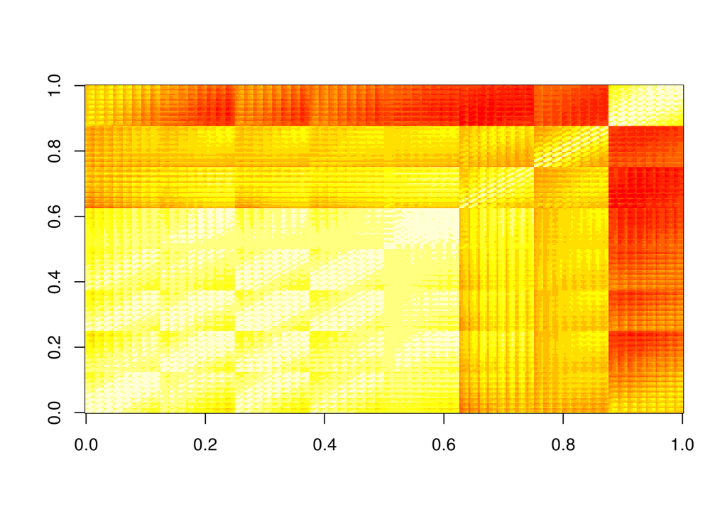

```r
load("~/Dropbox/M1966_DataMining/datasets/meteo.RData")
aux1 <- cor(x)
image(aux1)
```

En la imagen se aprecia como existe una correlación muy alta entre parte de los predictores, de modo que la aplicación directa de un modelo de regresión lineal puede dar lugar a problemas por la colinealidad de parte de los predictores. Del mismo modo, la consideración de diferentes campos atmosféricos (presión, humedad, temperatura, etc…) como predictores, los cuales suelen presentar órdenes de magnitud muy diferentes

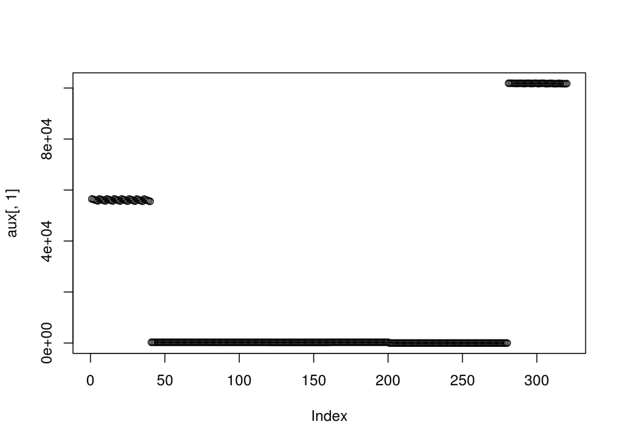

```r
aux <- matrix(data = NA, nrow = ncol(x), 2)
aux[,1] <- apply(x, MARGIN = 2, FUN = mean, na.rm = TRUE)
aux[,2] <- apply(x, MARGIN = 2, FUN = sd, na.rm = TRUE)
par(mfrow=c(1,1))
plot(aux[,1])
```

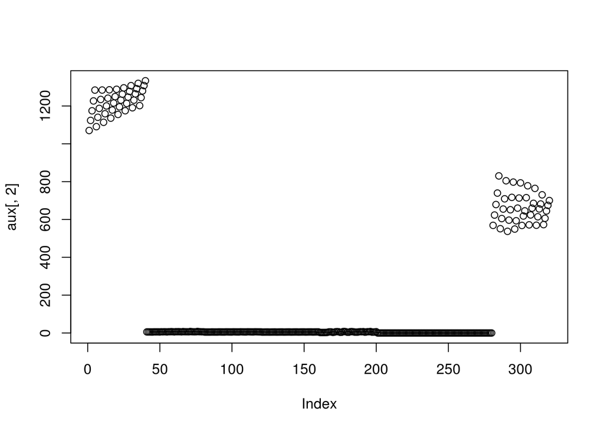

```r
plot(aux[,2])
```

hace necesaria la inclusión de la estandarización en el cálculo de las PCs.

En este apartado analizaremos ambos problemas. Para ello construimos el dataframe que nos permita realizar el ajuste:

```r
meteo <- data.frame(predictors = x, predictand = y)

indTrain <- createDataPartition(meteo$predictand, p=0.5, list=FALSE)
trainHO <- meteo[indTrain,]
testHO <- meteo[-indTrain,]

rawLinearModel <- lm(predictand ~ ., data = trainHO)
Npcs <- 1:ncol(x)
rSquare <- matrix(data = NA, nrow = 1+length(Npcs), 4)
asd <- summary(rawLinearModel)
rSquare[1,1] <- asd$r.squared
rSquare[1,2] <- asd$adj.r.squared
yest <- predict(rawLinearModel, trainHO)
rSquare[1,3] <- sqrt(mean((yest-trainHO$predictand)^2, na.rm = TRUE))
yest <- predict(rawLinearModel, testHO)
rSquare[1,4] <- sqrt(mean((yest-testHO$predictand)^2, na.rm = TRUE))
```

Analizamos primero las PCs para ver cuantas son apropiadas para el ajuste:

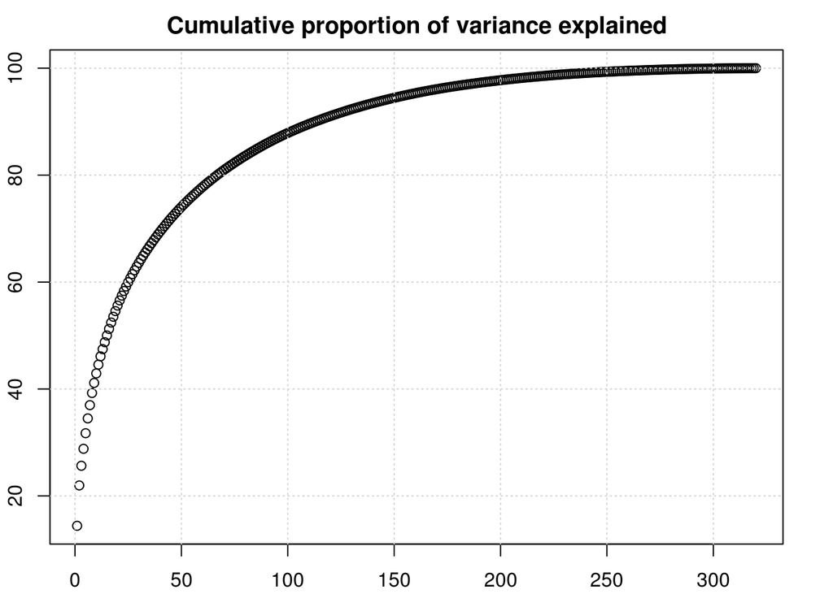

```r
# PCA with R
PCA <- prcomp(trainHO[,(1:ncol(x))], center = TRUE, scale. = TRUE)
par(mfrow=c(1,1), mar=c(2.1,2.1,2.1,2.1))
plot(cumsum(PCA$sdev)/sum(PCA$sdev)*100,main="Cumulative proportion of variance explained")
grid()
```

Según el gráfico, con 100 PCs explicamos el 90% de la varianza. Veamos como varían las medidas de validación del modelo lineal al incluir más PCs:

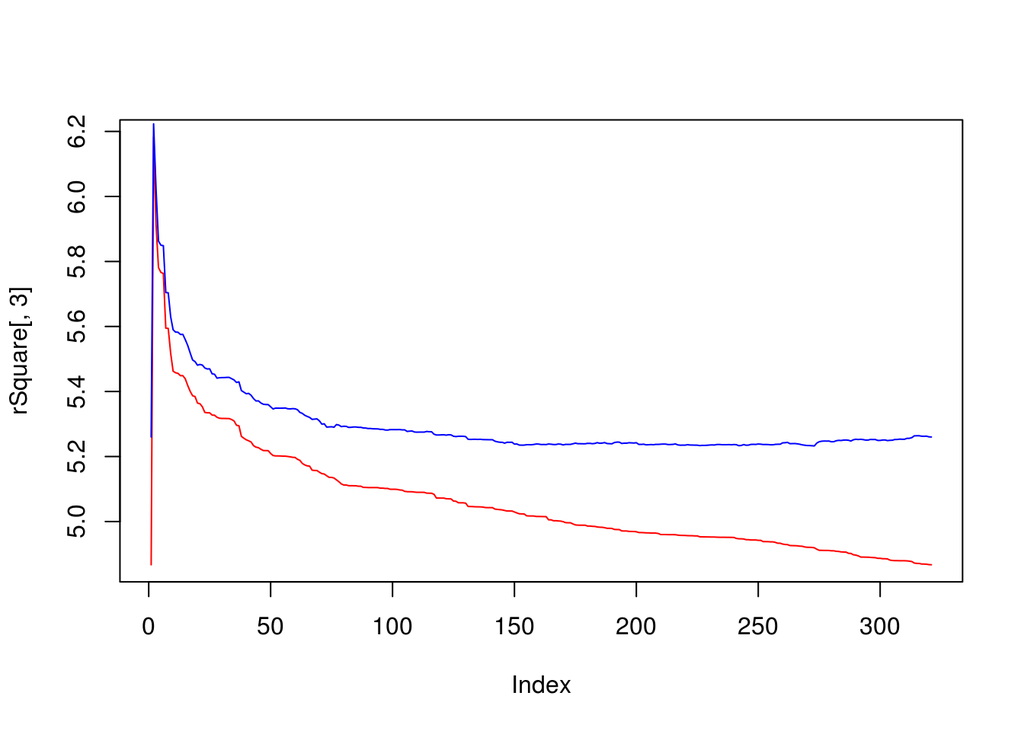

```r
for (i in 1:length(Npcs)){
  trainHO$x <- PCA$x[,1:Npcs[i]]
  pcLinearModel <- lm(predictand ~ x, data = trainHO)
  asd <- summary(pcLinearModel)
  rSquare[1+i,1] <- asd$r.squared
  rSquare[1+i,2] <- asd$adj.r.squared
  aux <- predict(PCA, testHO)
  testHO$x <- aux[,1:i]
  yest <- predict(pcLinearModel, trainHO)
  rSquare[1+i,3] <- sqrt(mean((yest-trainHO$predictand)^2, na.rm = TRUE))
  yest <- predict(pcLinearModel, testHO)
  rSquare[1+i,4] <- sqrt(mean((yest-testHO$predictand)^2, na.rm = TRUE))
}
par(mfrow=c(1,1))
plot(rSquare[,3], type = "l", col = "red")
lines(rSquare[,4], col = "blue")
```

# 5 Reducción de la dimensionalidad con LDA

Aunque inicialmente fue creado como clasificador, el discriminante lineal (LDA) puede verse también como un algoritmo de reducción de la dimensión para variables categóricas. Es decir, a diferencia del análisis de componentes principales, el LDA hace uso de las categorías para realizar la reducción de la dimensión siendo, en los problemas de clasificación, una alternativa a PCA.

Para ilustrar esta dualidad, aplicaremos el algoritmo tanto como clasificador como para reducir la dimensionalidad de los datos de entrada. Notar que ésta última propiedad permite combinar LDA con otros modelos/métodos de clasificación (GLMs, NNs, etc.).

Para ello consideraremos de nuevo el dataset MNIST:

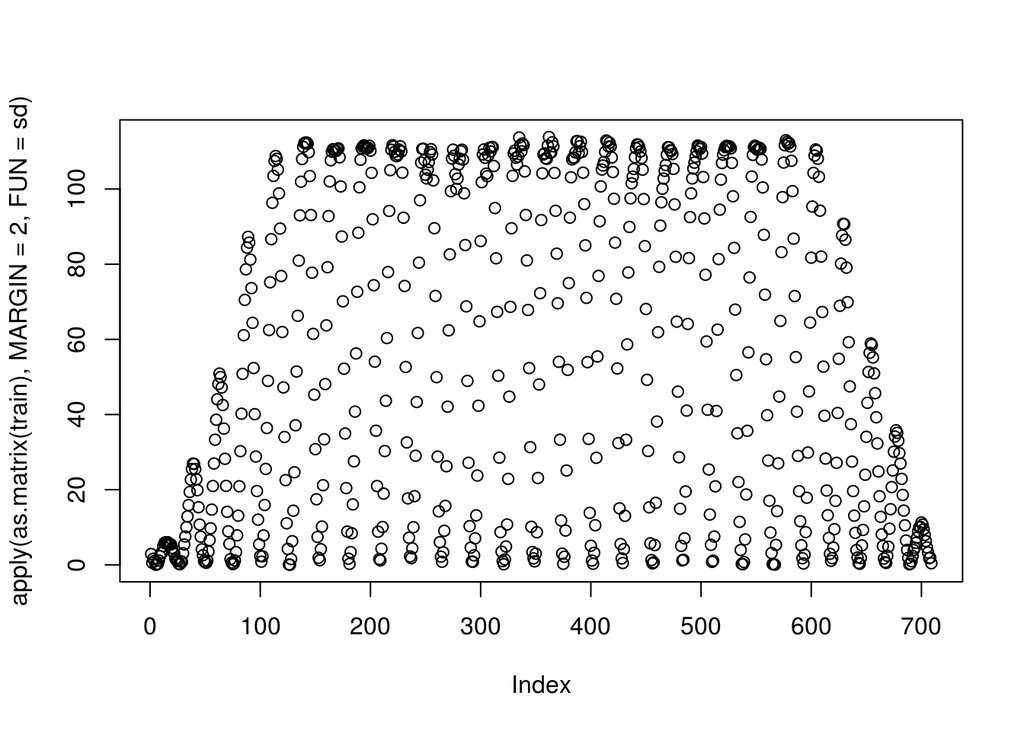

```r
# Reading dataset
library(MASS)
library(readr)
library(caret)
train <- read_csv("~/Dropbox/M1966_DataMining/datasets/train.csv")
# Filtering the constant pixels
train <- train[which(apply(as.matrix(train), MARGIN = 2, FUN = sd) != 0)]

plot(apply(as.matrix(train), MARGIN = 2, FUN = sd))
```

```r
train$label[which(train$label < 9)] <- 0
train$label[which(train$label == 9)] <-1
train$label<-as.factor(train$label)

indTrain <- createDataPartition(train$label,p=0.5,list=FALSE)
trainHO <- train[indTrain,]
testHO <- train[-indTrain,]
fitControl <- trainControl(method="none")
```

## 5.1 Clasificador LDA

LDA está implementado en el paquete MASS de R, y su uso es muy similar al de otros modelos lineales ya vistos, como `lm`.

```r
? lda
```

Además de los datos, el algoritmo permite definir las probabilidades a priori de los grupos. En caso de no incluirse este parámetro considerará las del conjunto de entrenamiento.

```r
# Model Discriminant Analysis
model <- lda(label ~ ., trainHO[which(apply(as.matrix(trainHO), MARGIN = 2, FUN = sd)!=0)])

# Model Testing
model.results <- predict(model, testHO[which(apply(as.matrix(trainHO), MARGIN = 2, FUN = sd)!=0)])

# Results - Confusion Matrix
t <- table(model.results$class, testHO$label)
print(confusionMatrix(t))

# Model Testing on trainning data
model.results <- predict(model, trainHO[which(apply(as.matrix(trainHO), MARGIN = 2, FUN = sd)!=0)])

# Results - Confusion Matrix
t <- table(model.results$class, trainHO$label)
print(confusionMatrix(t))
```

[output not shown]

Por un lado, al igual que ocurre con los modelos lineales, la principal componente del modelo en este caso es la matriz de coeficientes ya que describe un nuevo espacio sobre el cual se proyectan los datos y en el cual puede darse la reducción de dimensionalidad buscada. En particular, LDA reduce el espacio a C-1 dimensiones, siendo C el número de clases, en nuestro caso 2. Por ello, el atributo `scaling` del modelo contiene únicamente un vector.

Notar que, considerando este vector de coeficientes, y proyectando las dimensiones originales sobre él, el algoritmo LDA tiene implícita una reducción de la dimensión, de ahí que pueda utilizarse para este fin como alternativa de las PCs en el caso de problemas de clasificación.

Por otro lado, vemos como la precisión como clasificador del LDA es del 95% tanto sobre el conjunto de test como de train, siendo un método apropiado en este caso. Como es de esperar por la formulación del método, éste obtendrá mejores resultados en el caso de propiedades linealmente separables. Cuando no existe esta propiedad, el LDA presentará mayores errores y habrá que considerar otras técnicas no lineales como redes neuronales o SVMs, que se verán en las asignaturas de Machine Learning.

# 6 Tarea: Regularización, selección de variables y reducción de la dimensionalidad

En la presente tarea se aplicarán las diferentes aproximaciones para analizar los resultados de todas ellas, tanto desde el punto de vista de la reducción de la dimensión como de su precisión como modelo de clasificación y/o regresión.

Considerar el conjunto de datos MNIST ya utilizado en diferentes ocasiones. Como hemos visto, por un lado, en dicho dataset existen dimensiones/píxeles que no aportan información al modelo. Por otro lado, en virtud del análisis de PCs realizado existe información redundante que puede ser `redefinida`. Finalmente, y haciendo uso del atributo `label` del dataset, podemos aplicar diferentes técnicas, incluida el LDA, para ajustar un modelo que clasifique los dígitos.

Por lo tanto, en la presente tarea se pide que, trabajando únicamente con un conjunto de train y otro de test:

- Se considere cualquiera de los 10 dígitos y se entrene un `glm` aplicando los dos términos de regularización considerados, alguno de los algoritmos de selección de variables, PCs y LDA. A partir de los resultados, ¿qué modelo obtiene un mejor ajuste para el conjunto de train?, ¿y de test? ¿Qué aproximación da lugar a una mayor reducción de la dimensionalidad y, por tanto, de la complejidad del modelo?
- ¿El proceso de regularización y/o selección de variables es capaz de, entre otras, `filtrar` las dimensiones espúreas?
- Finalmente, el algoritmo LDA permite una clasificación multicategórica, aplicadlo al conjunto de datos MNIST y describid brevemente los resultados.

# 7 Créditos y recursos adicionales

- Gutiérrez, J.M., Cano, R., Cofiño, A.S., Sordo, C., 2004. Redes probabilísticas y neuronales en las ciencias atmosféricas. Centro de Publicaciones, Ministerio de Medio Ambiente, Madrid, Spain [URL:](http://www.meteo.unican.es/en/books/dataMiningMeteo).
- James, G., Witten, D., Hastie, T., Tibshirani, R., 2013. An Introduction to Statistical Learning, Springer Texts in Statistics. Springer New York, New York, NY. [URL:](http://www-bcf.usc.edu/~gareth/ISL/).
- Sánchez, G. Visualizing Dendrograms in R. [URL:](http://rstudio-pubs-static.s3.amazonaws.com/1876_df0bf890dd54461f98719b461d987c3d.html).
- Peña, D. Análisis de Datos Multivariantes, 1st ed. McGraw Hill.
- Crawley, M.J., 2007. The R book. Wiley, Chichester, England
- Everitt, B., Hothorn, T., 2011. An Introduction to Applied Multivariate Analysis with R. Springer New York, New York, NY.
- Ali, S. Hadi y Robert F. 1998. Some Cautionary Notes on the Use of Principal Components Regression. The American Statistician, 52 (1), 15-19, doi: 10.1080/00031305.1998.10480530
- Fernandes, M.D.Is LDA a dimensionality reduction technique or a classifier algorithm? [URL:](https://towardsdatascience.com/is-lda-a-dimensionality-reduction-technique-or-a-classifier-algorithm-eeed4de9953a).
- Burges, C.J.C., 2010, Dimension Reduction: A Guided Tour, Foundations and Trends in Machine Learning, 2(4):275, doi: http://dx.doi.org/10.1561/2200000002.